# R Code for Portfolio Optimization Chapter 11 – Risk Parity Portfolios

Daniel P. Palomar (2025). [Portfolio Optimization: Theory and Application.](https://portfoliooptimizationbook.com/) Cambridge University Press.

Last update: March 14, 2025

# Loading packages

The following packages are used in the examples:

```r
# basic finance
library(xts)                    # to manipulate time series of stock data
library(pob)                    # book package with financial data

# plotting
library(ggplot2)                # for nice plots
library(reshape2)               # to reshape data
library(dplyr)                  # for data frame manipulation (e.g., mutate)
library(patchwork)              # for combining plots
library(scales)                 # for axes control

# optimization
library(alabama)
library(nloptr)
library(quadprog)
library(riskParityPortfolio)    # for risk parity portfolios
library(microbenchmark)         # for cpu computation
```

# From dollar to risk diversification

Portfolio allocation and risk allocation for the $1/N$ portfolio and risk parity portfolio:

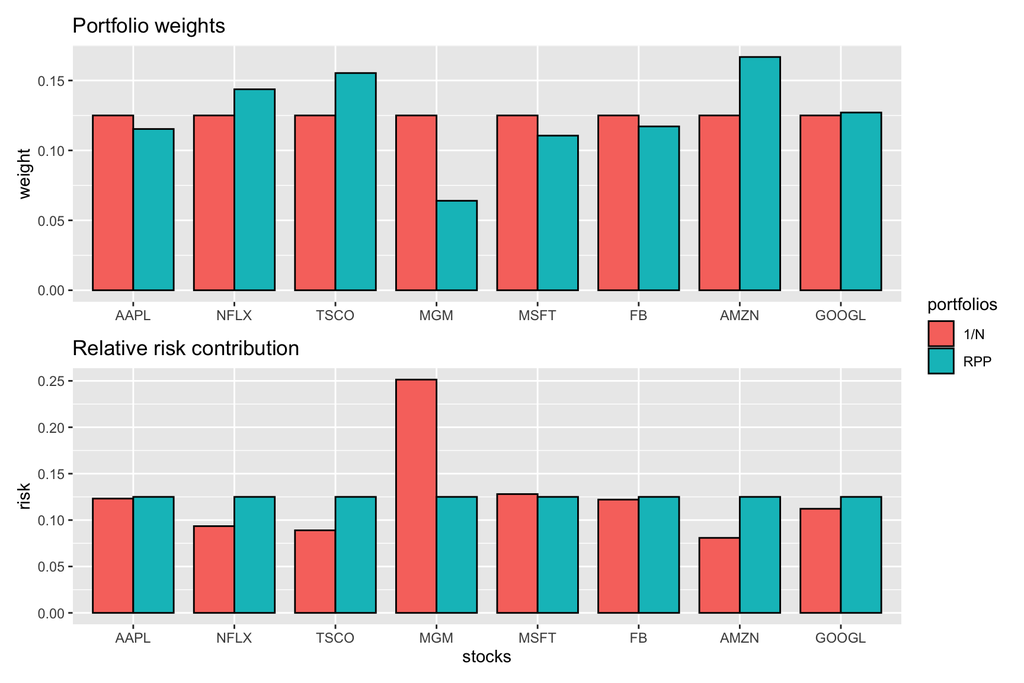

```r
library(pob)
library(riskParityPortfolio)

stock_prices <- SP500_2015to2020$stocks["2020::2020-09", c("AAPL", "NFLX", "TSCO", "MGM", "MSFT", "FB", "AMZN", "GOOGL")]
T <- nrow(stock_prices)
T_trn <- round(0.70*T)
X <- diff(log(stock_prices[1:T_trn, ]))[-1]
Sigma <- cov(X)
N <- ncol(X)


# portfolios
w_EWP <- rep(1/N, N)
w_RPP <- riskParityPortfolio(Sigma)$w

# barplots
df_w <- data.frame(
  "stocks"  = names(stock_prices),
  "1/N"     = w_EWP,
  "RPP"     = w_RPP,
  check.names = FALSE)

# Using package riskParityPortfolio:
# barplotPortfolioRisk(as.matrix(df_w[-1]), Sigma)

# We define our own barplot function for completeness:
barplot_w_and_RCC <- function(df_w, Sigma) {
  df_w$stocks <- factor(df_w$stocks, levels = unique(df_w$stocks))

  # get relative risk contribution
  df_rrc <- df_w
  df_rrc[-1] <- lapply(as.list(df_w[-1]), function(w) {
    rc <- as.vector(w * (Sigma %*% w))
    rc/sum(rc)
    })

  # plots
  p_w <- df_w |>
    melt(id.vars = "stocks") |>
    ggplot(aes(x = stocks, y = value, fill = variable)) +
    geom_bar(stat = "identity", position = "dodge", color = "black", width = 0.8) +
    labs(fill = "portfolios") +
    labs(title = "Portfolio weights", x = NULL, y = "weight")

  p_rrc <- df_rrc |>
    melt(id.vars = "stocks") |>
    ggplot(aes(x = stocks, y = value, fill = variable)) +
    geom_bar(stat = "identity", position = "dodge", color = "black", width = 0.8) +
    labs(fill = "portfolios") +
    labs(title = "Relative risk contribution", y = "risk")

  p_w / p_rrc + plot_layout(guides = "collect")
}

barplot_w_and_RCC(df_w, Sigma)
```

# Naive diagonal formulation

Portfolio allocation and risk contribution of the $1/N$ portfolio and naive RPP:

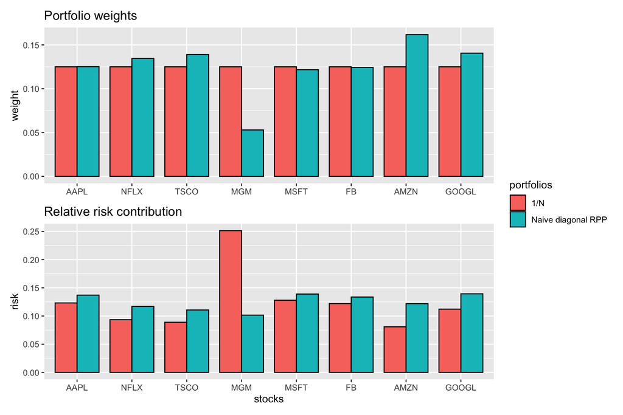

```r
library(pob)
library(riskParityPortfolio)

stock_prices <- SP500_2015to2020$stocks["2020::2020-09", c("AAPL", "NFLX", "TSCO", "MGM", "MSFT", "FB", "AMZN", "GOOGL")]
T <- nrow(stock_prices)
T_trn <- round(0.70*T)
X <- diff(log(stock_prices[1:T_trn, ]))[-1]
Sigma <- cov(X)
N <- ncol(X)


# portfolios
w_EWP <- rep(1/N, N)
#w_naive_RPP <- riskParityPortfolio(Sigma, formulation = "diag")$w
w_naive_RPP <- 1/sqrt(diag(Sigma))
w_naive_RPP <- w_naive_RPP/sum(w_naive_RPP)


# barplots
df_w <- data.frame(
  "stocks"    = names(stock_prices),
  "1/N"                = w_EWP,
  "Naive diagonal RPP" = w_naive_RPP,
  check.names = FALSE)

barplot_w_and_RCC(df_w, Sigma)
```

# Vanilla convex formulations

Portfolio allocation and risk contribution of the vanilla convex RPP compared to benchmarks:

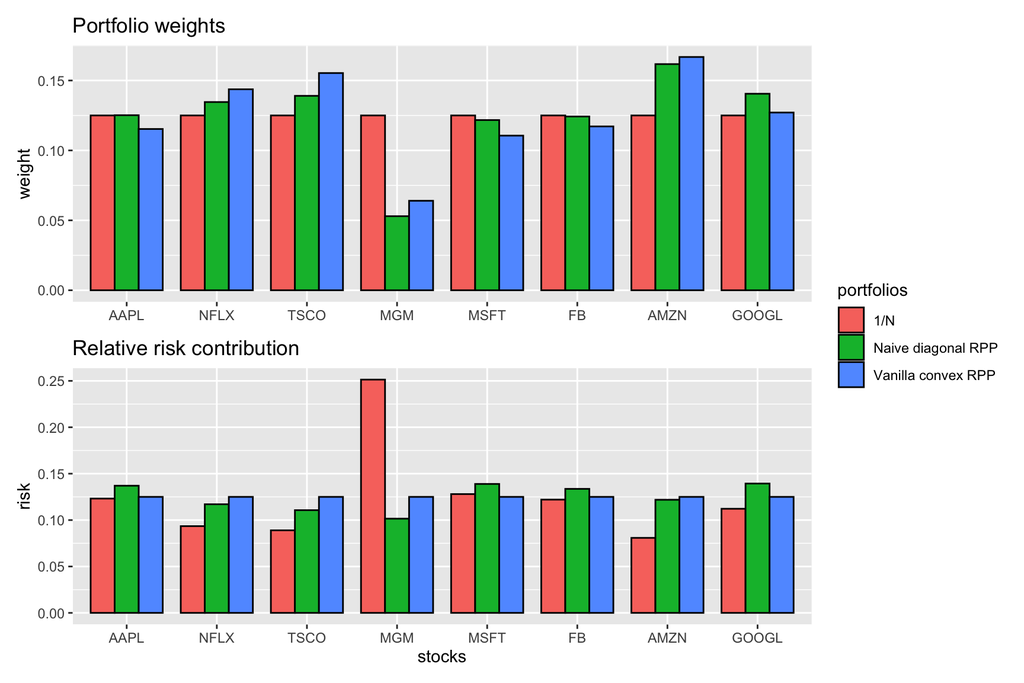

```r
library(riskParityPortfolio)

stock_prices <- SP500_2015to2020$stocks["2020::2020-09", c("AAPL", "NFLX", "TSCO", "MGM", "MSFT", "FB", "AMZN", "GOOGL")]
T <- nrow(stock_prices)
T_trn <- round(0.70*T)
X <- diff(log(stock_prices[1:T_trn, ]))[-1]
Sigma <- cov(X)
N <- ncol(X)


# portfolios
w_EWP <- rep(1/N, N)
w_naive_RPP  <- riskParityPortfolio(Sigma, formulation = "diag")$w
w_convex_RPP <- riskParityPortfolio(Sigma)$w


# barplots
df_w <- data.frame(
  "stocks"    = names(stock_prices),
  "1/N"                = w_EWP,
  "Naive diagonal RPP" = w_naive_RPP,
  "Vanilla convex RPP" = w_convex_RPP,
  check.names = FALSE)

barplot_w_and_RCC(df_w, Sigma)
```

## Algorithms

### General-purpose nonlinear solver

We can solve this problem with the general-purpose nonlinear solver `optim()` in R:

```r
# initial point
w <- rep(1/N, N)
x0 <- w/as.numeric(sqrt(w %*% Sigma %*% w))

# function definition
fn_convex <- function(x, Sigma) {
  N <- nrow(Sigma)
  return(0.5 * t(x) %*% Sigma %*% x - (1/N)*sum(log(x)))
}

# optimize with general-purpose solver
result <- optim(par = x0, fn = fn_convex, Sigma = Sigma, method = "BFGS")
x_general_solver <- result$par
w_general_solver_RPP <- x_general_solver/sum(x_general_solver)

# sanity check of the solution
b <- rep(1/N, N)
Sigma %*% x_general_solver - b/x_general_solver
```

```
               [,1]
AAPL  -7.391053e-06
NFLX  -1.951736e-05
TSCO  -9.158081e-06
MGM    9.466781e-06
MSFT   8.160602e-06
FB    -1.373207e-05
AMZN  -3.604614e-05
GOOGL -3.071543e-05
```

### Newton’s method

Newton’s method for Spinu’s RPP formulation:

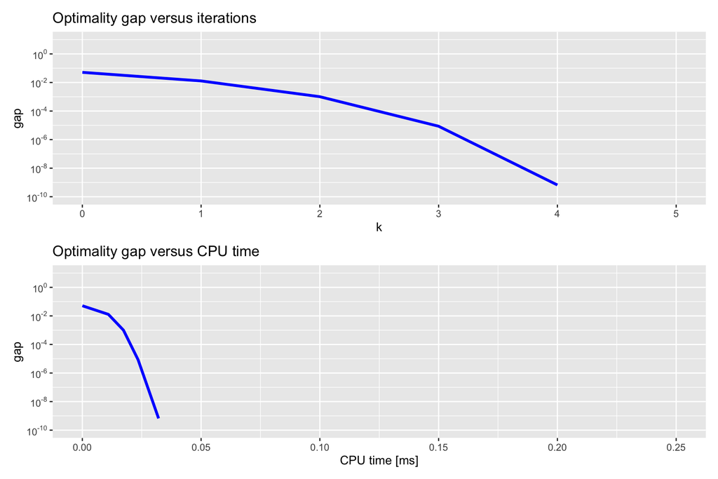

```r
library(microbenchmark)
library(dplyr)

b <- rep(1/N, N)
x_opt <- w_convex_RPP / as.vector(sqrt(w_convex_RPP %*% Sigma %*% w_convex_RPP))
opt_value <- 0.5 * x_opt %*% Sigma %*% x_opt - b %*% log(x_opt)

#
# Newton Spinu algorithm  (1/N initial point)
#
num_iter <- 5L
w <- rep(1/N, N)
x <- w/as.numeric(sqrt(w %*% Sigma %*% w))
df <- data.frame("k"          = 0L,
                 "cpu time k" = 0,
                 "obj_value"  = 0.5 * x %*% Sigma %*% x - b %*% log(x),
                 "gap"        = 0.5 * x %*% Sigma %*% x - b %*% log(x) - opt_value,
                 check.names      = FALSE)

for (k in 1:num_iter) {
  cpu_time <- microbenchmark({
    grad <- Sigma %*% x - b/x
    Hessian <- Sigma + diag(b/x^2)
    x_new <- x - solve(Hessian, grad)
    }, unit = "microseconds", times = 10L)$time |> median()
  x <- as.numeric(x_new)

  df <- rbind(df, list("k"          = k,
                       "cpu time k" = cpu_time,
                       "obj_value"  = 0.5 * x %*% Sigma %*% x - b %*% log(x),
                       "gap"        = 0.5 * x %*% Sigma %*% x - b %*% log(x) - opt_value))
}
df <- df |> mutate("CPU time [ms]" = cumsum(`cpu time k`)/1e6)

p_gap_vs_iter <- df |>
  ggplot(aes(x = k, y = gap)) +
  geom_line(linewidth = 1.2, col = "blue") +
  scale_y_log10(breaks = trans_breaks("log10", function(x) 10^x), labels = trans_format("log10", math_format(10^.x))) +
  scale_x_continuous(limits = c(0, num_iter), breaks = seq(0, num_iter, by = 1), minor_breaks = NULL) +
  coord_cartesian(ylim = c(1e-10, 1e1)) +
  ggtitle("Optimality gap versus iterations")

p_gap_vs_cpu_time <- df |>
  ggplot(aes(x = `CPU time [ms]`, y = gap, color = method)) +
  geom_line(linewidth = 1.2, col = "blue") +
  scale_y_log10(breaks = trans_breaks("log10", function(x) 10^x), labels = trans_format("log10", math_format(10^.x))) +
  coord_cartesian(xlim = c(0, 0.25), ylim = c(1e-10, 1e1)) +
  ggtitle("Optimality gap versus CPU time")

p_gap_vs_iter / p_gap_vs_cpu_time + plot_layout(guides = "collect")
```

### Cyclical coordinate descent algorithm

Cyclical coordinate descent algorithm for Spinu’s RPP formulation:

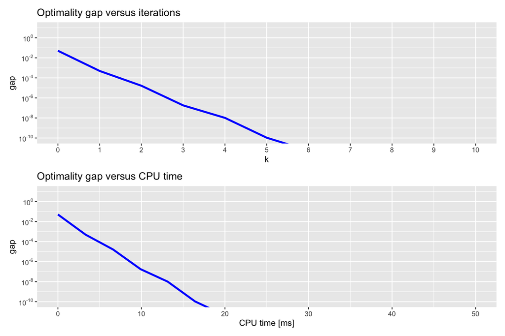

```r
#
# Cyclical Spinu coordinate descent algorithm (1/N initial point)
#
num_iter <- 10L
w <- rep(1/N, N)
x <- w/as.numeric(sqrt(w %*% Sigma %*% w))
df <- data.frame("k"          = 0L,
                 "cpu time k" = 0,
                 "obj_value"  = 0.5 * x %*% Sigma %*% x - b %*% log(x),
                 "gap"        = 0.5 * x %*% Sigma %*% x - b %*% log(x) - opt_value,
                 check.names      = FALSE)

for (k in 1:num_iter) {
  cpu_time <- microbenchmark({
    x_new <- x
    #Sigma_xk <- as.numeric(Sigma %*% x_new)
    for (i in 1:N) {
      Sigma_xk_i <- as.numeric(x_new[-i] %*% Sigma[-i, i])
      #Sigma_xk_i <- Sigma_xk[i] - x_new[i] * Sigma[i, i]
      x_new[i] <- (- Sigma_xk_i + sqrt(Sigma_xk_i^2 + 4*Sigma[i, i]*b[i]))/(2*Sigma[i, i])
      #x_diff <- x_new[i] - x[i]
      #Sigma_xk <- Sigma_xk + Sigma[, i] * x_diff
    }
    }, unit = "microseconds", times = 10L)$time |> median()
  x <- as.numeric(x_new)

  df <- rbind(df, list("k"          = k,
                       "cpu time k" = cpu_time,
                       "obj_value"  = 0.5 * x %*% Sigma %*% x - b %*% log(x),
                       "gap"        = 0.5 * x %*% Sigma %*% x - b %*% log(x) - opt_value))
}
df <- df |> mutate("CPU time [ms]" = cumsum(`cpu time k`)/1e6)

p_gap_vs_iter <- df |>
  ggplot(aes(x = k, y = gap)) +
  geom_line(linewidth = 1.2, col = "blue") +
  scale_y_log10(breaks = trans_breaks("log10", function(x) 10^x), labels = trans_format("log10", math_format(10^.x))) +
  scale_x_continuous(limits = c(0, num_iter), breaks = seq(0, num_iter, by = 1), minor_breaks = NULL) +
  coord_cartesian(ylim = c(1e-10, 1e1)) +
  ggtitle("Optimality gap versus iterations")

p_gap_vs_cpu_time <- df |>
  ggplot(aes(x = `CPU time [ms]`, y = gap, color = method)) +
  geom_line(linewidth = 1.2, col = "blue") +
  scale_y_log10(breaks = trans_breaks("log10", function(x) 10^x), labels = trans_format("log10", math_format(10^.x))) +
  coord_cartesian(xlim = c(0, 50), ylim = c(1e-10, 1e1)) +
  ggtitle("Optimality gap versus CPU time")

p_gap_vs_iter / p_gap_vs_cpu_time + plot_layout(guides = "collect")
```

### Numerical comparison

```r
num_iter  <- 25L

sigma <- sqrt(diag(Sigma))
C <- cov2cor(Sigma)

#
# Newton Spinu algorithm
#
x <- sqrt(b)/sqrt(rowSums(Sigma))
df <- data.frame("k"          = 0L,
                 "cpu time k" = 0,
                 "obj_value"  = 0.5 * x %*% Sigma %*% x - b %*% log(x),
                 "gap"        = 0.5 * x %*% Sigma %*% x - b %*% log(x) - opt_value,
                 "method"     = "Newton",
                 check.names      = FALSE)
for (k in 1:num_iter) {
  cpu_time <- microbenchmark({
    grad <- Sigma %*% x - b/x
    Hessian <- Sigma + diag(b/x^2)
    x_new <- x - solve(Hessian, grad)
    }, unit = "microseconds", times = 10L)$time |> median()
  x <- as.numeric(x_new)

  df <- rbind(df, list("k"          = k,
                       "cpu time k" = cpu_time,
                       "obj_value"  = 0.5 * x %*% Sigma %*% x - b %*% log(x),
                       "gap"        = 0.5 * x %*% Sigma %*% x - b %*% log(x) - opt_value,
                       "method"     = "Newton"))
}



#
# Newton Spinu algorithm (normalized and based on correlation matrix)
#
x <- sqrt(b)/sqrt(rowSums(C))
rowsum_C <- rowSums(C)
df <- rbind(df, list("k"          = 0L,
                     "cpu time k" = 0,
                     "obj_value"  = 0.5 * (x/sigma) %*% Sigma %*% (x/sigma) - b %*% log(x/sigma),
                     "gap"        = 0.5 * (x/sigma) %*% Sigma %*% (x/sigma) - b %*% log(x/sigma) - opt_value,
                     "method"     = "Newton - improved"))
for (k in 1:num_iter) {
  cpu_time <- microbenchmark({
    grad <- C %*% x - b/x
    Hessian <- C + diag(b/x^2)
    x_new <- x - solve(Hessian, grad)
    x_new <- x_new * sqrt(sum(b/x_new)/sum(rowsum_C * x_new))
    }, unit = "microseconds", times = 10L)$time |> median()
  x <- as.numeric(x_new)

  df <- rbind(df, list("k"          = k,
                       "cpu time k" = cpu_time,
                       "obj_value"  = 0.5 * (x/sigma) %*% Sigma %*% (x/sigma) - b %*% log(x/sigma),
                       "gap"        = 0.5 * (x/sigma) %*% Sigma %*% (x/sigma) - b %*% log(x/sigma) - opt_value,
                       "method"     = "Newton - improved"))
}



#
# Parallel Spinu MM
#
x <- sqrt(b)/sqrt(rowSums(Sigma))
df <- rbind(df, list("k"          = 0L,
                     "cpu time k" = 0,
                     "obj_value"  = 0.5 * x %*% Sigma %*% x - b %*% log(x),
                     "gap"        = 0.5 * x %*% Sigma %*% x - b %*% log(x) - opt_value,
                     "method"     = "MM"))
lmd_max <- eigen(Sigma)$values[1]
Sigma_lmd_max <- Sigma - lmd_max*diag(N)
for (k in 1:num_iter) {
  cpu_time <- microbenchmark({
    Sigma_lmd_max_xk <- Sigma_lmd_max %*% x
    x_new <- (-Sigma_lmd_max_xk + sqrt(Sigma_lmd_max_xk^2 + 4*lmd_max*b))/(2*lmd_max)
    }, unit = "microseconds", times = 10L)$time |> median()
  x <- as.numeric(x_new)

  df <- rbind(df, list("k"          = k,
                       "cpu time k" = cpu_time,
                       "obj_value"  = 0.5 * x %*% Sigma %*% x - b %*% log(x),
                       "gap"        = 0.5 * x %*% Sigma %*% x - b %*% log(x) - opt_value,
                       "method"     = "MM"))
}


#
# Parallel Spinu MM (normalized and based on correlation matrix)
#
x <- sqrt(b)/sqrt(rowSums(C))
rowsum_C <- rowSums(C)
df <- rbind(df, list("k"          = 0L,
                     "cpu time k" = 0,
                     "obj_value"  = 0.5 * (x/sigma) %*% Sigma %*% (x/sigma) - b %*% log(x/sigma),
                     "gap"        = 0.5 * (x/sigma) %*% Sigma %*% (x/sigma) - b %*% log(x/sigma) - opt_value,
                     "method"     = "MM - improved"))
lmd_max <- eigen(C)$values[1]
C_lmd_max <- C - lmd_max*diag(N)
for (k in 1:num_iter) {
  cpu_time <- microbenchmark({
    C_lmd_max_xk <- C_lmd_max %*% x
    x_new <- (-C_lmd_max_xk + sqrt(C_lmd_max_xk^2 + 4*lmd_max*b))/(2*lmd_max)
    x_new <- x_new * sqrt(sum(b/x_new)/sum(rowsum_C * x_new))
    }, unit = "microseconds", times = 10L)$time |> median()
  x <- as.numeric(x_new)

  df <- rbind(df, list("k"          = k,
                       "cpu time k" = cpu_time,
                       "obj_value"  = 0.5 * (x/sigma) %*% Sigma %*% (x/sigma) - b %*% log(x/sigma),
                       "gap"        = 0.5 * (x/sigma) %*% Sigma %*% (x/sigma) - b %*% log(x/sigma) - opt_value,
                       "method"     = "MM - improved"))
}


#
# Parallel Spinu SCA
#
x <- sqrt(b)/sqrt(rowSums(Sigma))
gamma <- 1   #(1, 0.1), (0.9, 0.01)
eps <- 0.1
df <- rbind(df, list("k"          = 0L,
                     "cpu time k" = 0,
                     "obj_value"  = 0.5 * x %*% Sigma %*% x - b %*% log(x),
                     "gap"        = 0.5 * x %*% Sigma %*% x - b %*% log(x) - opt_value,
                     "method"     = "SCA"))
Sigma_Diag_Sigma <- Sigma - diag(diag(Sigma))
for (k in 1:num_iter) {
  cpu_time <- microbenchmark({
    Sigma_Diag_Sigma_xk <- Sigma_Diag_Sigma %*% x
    x_hat <- (-Sigma_Diag_Sigma_xk + sqrt(Sigma_Diag_Sigma_xk^2 + 4*diag(Sigma)*b))/(2*diag(Sigma))
    x_new <- gamma*x_hat + (1 - gamma)*x
    }, unit = "microseconds", times = 10L)$time |> median()
  x <- as.numeric(x_new)
  gamma <- gamma * (1 - eps*gamma)

  df <- rbind(df, list("k"          = k,
                       "cpu time k" = cpu_time,
                       "obj_value"  = 0.5 * x %*% Sigma %*% x - b %*% log(x),
                       "gap"        = 0.5 * x %*% Sigma %*% x - b %*% log(x) - opt_value,
                       "method"     = "SCA"))
}


#
# Parallel Spinu SCA (normalized and based on correlation matrix)
#
x <- sqrt(b)/sqrt(rowSums(C))
rowsum_C <- rowSums(C)
gamma <- 1   #(1, 0.1), (0.9, 0.01)
eps <- 0.1
df <- rbind(df, list("k"          = 0L,
                     "cpu time k" = 0,
                     "obj_value"  = 0.5 * (x/sigma) %*% Sigma %*% (x/sigma) - b %*% log(x/sigma),
                     "gap"        = 0.5 * (x/sigma) %*% Sigma %*% (x/sigma) - b %*% log(x/sigma) - opt_value,
                     "method"     = "SCA - improved"))
C_minus_I <- C - diag(N)
for (k in 1:num_iter) {
  cpu_time <- microbenchmark({
    C_minus_I_xk <- C_minus_I %*% x
    x_hat <- (-C_minus_I_xk + sqrt(C_minus_I_xk^2 + 4*b))/2
    #x_hat <- x_hat /sqrt(as.numeric(t(x_hat) %*% C %*% x_hat))
    x_hat <- x_hat * sqrt(sum(b/x_hat)/sum(rowsum_C * x_hat))  # my version
    x_new <- gamma*x_hat + (1 - gamma)*x
    }, unit = "microseconds", times = 10L)$time |> median()
  x <- as.numeric(x_new)
  gamma <- gamma * (1 - eps*gamma)

  df <- rbind(df, list("k"          = k,
                       "cpu time k" = cpu_time,
                       "obj_value"  = 0.5 * (x/sigma) %*% Sigma %*% (x/sigma) - b %*% log(x/sigma),
                       "gap"        = 0.5 * (x/sigma) %*% Sigma %*% (x/sigma) - b %*% log(x/sigma) - opt_value,
                       "method"     = "SCA - improved"))
}



# process data frame
df$method <- factor(df$method, levels = unique(df$method))
df <- df |>
  group_by(method) |>
  mutate("CPU time [ms]" = cumsum(`cpu time k`)/1e6) |>
  ungroup()


# plots
p_gap_vs_iter <- df |>
  ggplot(aes(x = k, y = gap, color = method)) +
  geom_line(linewidth = 1.2) +
  scale_y_log10(breaks = trans_breaks("log10", function(x) 10^x), labels = trans_format("log10", math_format(10^.x))) +
  scale_x_continuous(limits = c(0, num_iter), breaks = seq(0, num_iter, by = 1), minor_breaks = NULL) +
  coord_cartesian(ylim = c(1e-10, 1e-2)) +
  labs(color = "method")
  ggtitle("Optimality gap versus iterations")
```

```
$title
[1] "Optimality gap versus iterations"

attr(,"class")
[1] "labels"
```

```r
p_gap_vs_cpu_time <- df |>
  ggplot(aes(x = `CPU time [ms]`, y = gap, color = method)) +
  geom_line(linewidth = 1.2) +
  scale_y_log10(breaks = trans_breaks("log10", function(x) 10^x), labels = trans_format("log10", math_format(10^.x))) +
  coord_cartesian(xlim = c(0, 0.25), ylim = c(1e-10, 1e-2)) +
  labs(color = "method")
  ggtitle("Optimality gap versus CPU time")
```

```
$title
[1] "Optimality gap versus CPU time"

attr(,"class")
[1] "labels"
```

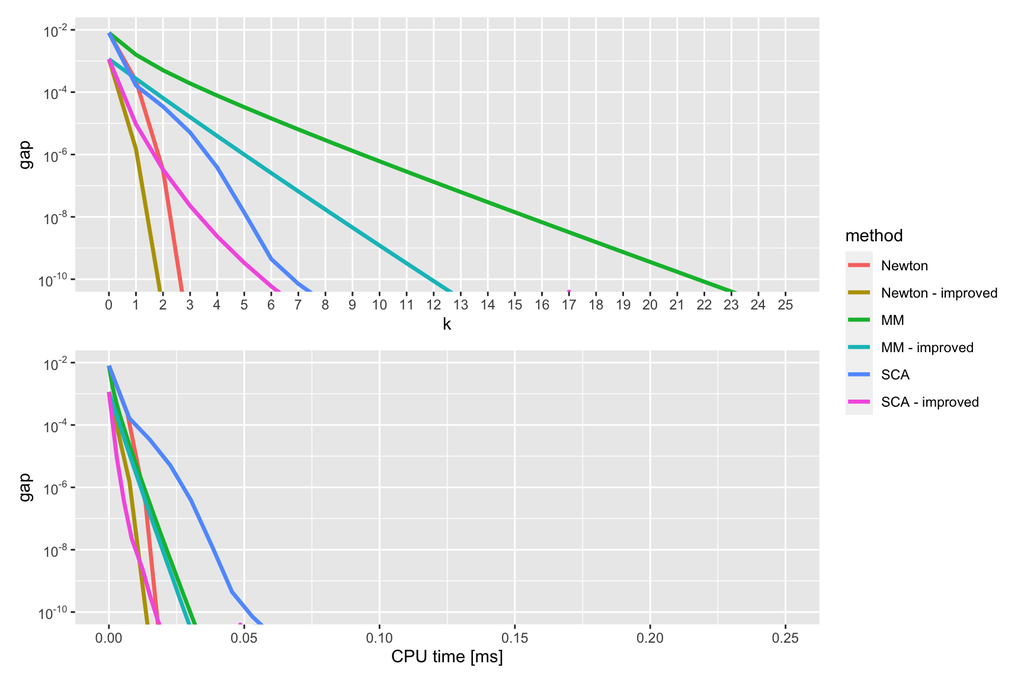

```r
p_gap_vs_iter / p_gap_vs_cpu_time + plot_layout(guides = "collect")
```

# General nonconvex formulations

Portfolio allocation and risk contribution of general nonconvex RPP (with $w_i \\leq 0.15$) compared to benchmarks ($1/N$ portfolio, naive diagonal RPP, and vanilla convex RPP):

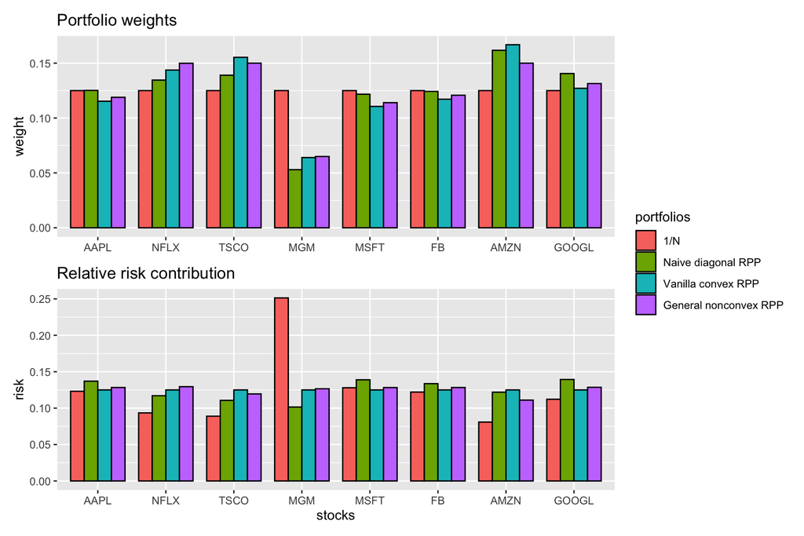

```r
library(riskParityPortfolio)

stock_prices <- SP500_2015to2020$stocks["2020::2020-09", c("AAPL", "NFLX", "TSCO", "MGM", "MSFT", "FB", "AMZN", "GOOGL")]
T <- nrow(stock_prices)
T_trn <- round(0.70*T)
X <- diff(log(stock_prices[1:T_trn, ]))[-1]
Sigma <- cov(X)
N <- ncol(X)

# portfolios
w_EWP <- rep(1/N, N)
w_naive_RPP  <- riskParityPortfolio(Sigma, formulation = "diag")$w
w_convex_RPP <- riskParityPortfolio(Sigma)$w
w_nonconvex_RPP <- riskParityPortfolio(Sigma, w_ub = 0.15)$w


# barplots
df_w <- data.frame(
  "stocks"    = names(stock_prices),
  "1/N"       = w_EWP,
  "Naive diagonal RPP" = w_naive_RPP,
  "Vanilla convex RPP" = w_convex_RPP,
  "General nonconvex RPP" = w_nonconvex_RPP,
  check.names = FALSE)

barplot_w_and_RCC(df_w, Sigma)
```

## Algorithms

Converge comparison for different algorithms to solve the nonconvex RPP formulation:
$$\begin{array}{ll}
\underset{\w}{\textm{minimize}} & \begin{aligned}\sum_{i=1}^N \left(\frac{w_i\left(\bSigma\w\right)_i}{\w^\T\bSigma\w} - b_i\right)^2\end{aligned}\\
\textm{subject to} & \w \in \mathcal{W}.
\end{array}$$

```r
library(riskParityPortfolio)
library(microbenchmark)
library(dplyr)
library(alabama)
library(nloptr)
library(quadprog)

N <- 200
Sigma <- cov(diff(log(SP500_2015to2020$stocks[, 1:N]))[-1])
b <- rep(1/N, N)
w_ub <- 0.008  # RPP with upper bound!!
w_init <- rep(1/N, N)

# problem definition
R      <- riskParityPortfolio:::R_rc_over_var_vs_b
R_grad <- riskParityPortfolio:::R_grad_rc_over_var_vs_b


num_iter  <- 20L
num_times <- 10L  # to compute the cpu time



#
# General nonlinear solver (alabama)
#
heq     <- function(w, ...) sum(w) - 1                         # sum(w) - 1 = 0
heq.jac <- function(w, ...) matrix(1, 1, N)
hin     <- function(w, ...) return(c(w, w_ub - w))             # w >= 0 and w <= ub (ub - w >= 0)
hin.jac <- function(w, ...) return(rbind(diag(N), -diag(N)))
w <- w_init
df <- data.frame("k"             = 0L,
                 "cpu time k"    = NA,
                 "CPU time [ms]" = 0,
                 "obj_value"     = R(w, Sigma, b),
                 "method"        = "nonlinear solver (alabama)",
                 check.names     = FALSE)
for (k in 1:num_iter) {
  cpu_time <- microbenchmark({
    res <- alabama::constrOptim.nl(par = w_init,
                                   fn  = R,    gr = R_grad,
                                   hin = hin,  hin.jac = hin.jac,
                                   heq = heq,  heq.jac = heq.jac,
                                   control.outer = list(trace = FALSE, itmax = k),
                                   Sigma = Sigma, b = b)
    w <- res$par
  }, unit = "microseconds", times = num_times)$time |> median()
  df <- rbind(df, list("k"             = res$outer.iterations,
                       "cpu time k"    = NA,
                       "CPU time [ms]" = cpu_time/1e6,
                       "obj_value"     = R(w, Sigma, b),
                       "method"        = "nonlinear solver (alabama)"))
}



#
# General nonlinear solver (nloptr)
#
w <- w_init
df <- rbind(df, list("k"             = 0L,
                     "cpu time k"    = NA,
                     "CPU time [ms]" = 0,
                     "obj_value"     = R(w, Sigma, b),
                     "method"        = "nonlinear solver (nloptr)"))
for (k in 1:num_iter) {
  cpu_time <- microbenchmark({
    res <- nloptr::slsqp(x0 = w_init,
                         fn = R,      gr = R_grad,
                         hin = hin,   hinjac = hin.jac,
                         heq = heq,   heqjac = heq.jac,
                         control = list(maxeval = k),
                         Sigma = Sigma, b = b)
    w <- res$par
  }, unit = "microseconds", times = num_times)$time |> median()
  df <- rbind(df, list("k"             = res$iter,
                       "cpu time k"    = NA,
                       "CPU time [ms]" = cpu_time/1e6,
                       "obj_value"     = R(w, Sigma, b),
                       "method"        = "nonlinear solver (nloptr)"))
}



#
# SCA
#
gamma <- 0.9
zeta <- 1e-7
# constraints (A' * b >= b0)
meq <- 1
Amat <- t(rbind(1, -diag(N), diag(N)))
bvec <- c(1, -rep(w_ub, N), rep(0, N))
# intermediate variables
tau <- .05 * sum(diag(Sigma)) / (2*N)
tauI <- tau*diag(N)
g <- riskParityPortfolio:::g_rc_over_var_vs_b
A <- riskParityPortfolio:::A_rc_over_var_vs_b

wk <- w_init
df <- rbind(df, list("k"             = 0L,
                     "cpu time k"    = 0,
                     "CPU time [ms]" = NA,
                     "obj_value"     = R(wk, Sigma, b),
                     "method"        = "SCA"))
for (k in 1:num_iter) {
  cpu_time <- microbenchmark({
    # auxiliary quantities
    Sigma_wk <- Sigma %*% wk
    rk <- wk * Sigma_wk
    Jk <- A(wk, Sigma, b, Sigma_w = Sigma_wk, r = rk)
    gk <- g(wk, Sigma, b, r = rk)
    Qk <- 2 * crossprod(Jk) + tauI
    qk <- 2 * t(Jk) %*% gk - Qk %*% wk
    w_hat <- quadprog::solve.QP(Dmat = Qk, dvec = -qk, Amat = Amat, bvec = bvec, meq = meq)$solution
    w_new <- wk + gamma * (w_hat - wk)
  }, unit = "microseconds", times = num_times)$time |> median()
  wk <- w_new
  gamma <- gamma * (1 - zeta*gamma)

  df <- rbind(df, list("k"             = k,
                       "cpu time k"    = cpu_time,
                       "CPU time [ms]" = NA,
                       "obj_value"     = R(wk, Sigma, b),
                       "method"        = "SCA"))
}


# process data frame
df$method <- factor(df$method, levels = unique(df$method))
df <- df |>
  group_by(method) |>
  mutate("CPU time [ms]" = ifelse(is.na(`CPU time [ms]`), cumsum(`cpu time k`)/1e6, `CPU time [ms]`)) |>
  ungroup()

# add optimality gap using the actual minimum value
df <- df |>
  group_by(method) |>
  mutate("gap" = obj_value - min(df$obj_value)) |>
  ungroup()


# plot
p_gap_vs_iter <- df |>
  ggplot(aes(x = k, y = gap, color = method)) +
  geom_line(linewidth = 1.2) +
  scale_y_log10(breaks = trans_breaks("log10", function(x) 10^x), labels = trans_format("log10", math_format(10^.x))) +
  scale_x_continuous(limits = c(0, num_iter), breaks = seq(0, num_iter, by = 1), minor_breaks = NULL) +
  #coord_cartesian(ylim = c(1e-10, 1e-2)) +
  labs(color = "method")
  ggtitle("Optimality gap versus iterations") + theme(axis.title.x = element_text(face = "italic"))
```

```r
p_gap_vs_cpu_time <- df |>
  ggplot(aes(x = `CPU time [ms]`, y = gap, color = method)) +
  geom_line(linewidth = 1.2) +
  scale_y_log10(breaks = trans_breaks("log10", function(x) 10^x), labels = trans_format("log10", math_format(10^.x))) +
  coord_cartesian(xlim = c(0, 250)) +
  labs(color = "method")
  ggtitle("Optimality gap versus CPU time")
```

```
$title
[1] "Optimality gap versus CPU time"

attr(,"class")
[1] "labels"
```

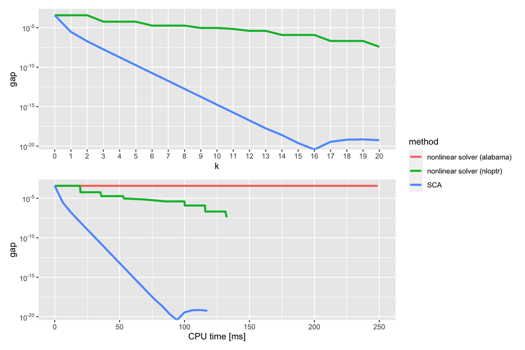

```r
p_gap_vs_iter / p_gap_vs_cpu_time + plot_layout(guides = "collect")
```

## References

Palomar, D. P. (2025). *Portfolio optimization: Theory and application*. Cambridge University Press.